# A-SA25204160-2025-10-20

SA25204160

2025-10-26

## Question

### T_1

在总共N=1000个假设中，950 个是零假设，50 个是备择假设。任何零假设下的 p 值服从均匀分布（使用R函数runif），任何备择假设下的 p 值服从参数为 0.1 和 1 的 Beta 分布（使用 R 函数 rbeta）。

获取 Bonferroni 校正后的 p 值和 Benjamini-Hochberg (B-H) 校正后的 p 值。

基于m=10000次模拟重复，在名义水平α = 0.1 下，计算每种校正方法的以下指标：FWER,FDR,TPR

你应该将一个包含 6 个数值的表格输出为3×2 格式（列名：Bonferroni correction, B-H correction；行名：FWER, FDR, TPR）。并对结果进行评论。

### 8.4

参照 boot 包中提供的空调数据集aircondit这12个观测值是空调设备故障间隔时间（单位：小时）[68, 例 1.1]：

3, 5, 7, 18, 43, 85, 91, 98, 100, 130, 230, 487。

假设故障间隔时间服从指数模型Exp(λ)。求风险率λ的最大似然估计，并使用自助法估计该估计量的偏差和标准误。

### 8.7

参照练习 8.6。Efron 和 Tibshirani 讨论了以下例子 [91,第7章]。五维分数数据有一个5×5 的协方差矩阵 Σ，其特征值为正且满足$\lambda _1>...>\lambda _5$。在主成分分析中：

$$\theta =\frac{\lambda _1}{\sum_{j=1}^{5}
\lambda_j}$$

$$\hat{\theta} =\frac{\hat{\lambda}
_1}{\sum_{j=1}^{5} \hat{\lambda}_j}$$

使用自助法估计$\hat{\theta}$的偏差和标准误差

## Answer

### T_1

#### 1

设置参数：N=1000，其中950个零假设，50个备择假设。模拟重复次数m=10000，名义水平α=0.1。

#### 2

步骤一：

每次模拟中：

生成950个零假设的p值：来自均匀分布runif(950)

生成50个备择假设的p值：来自rbeta(50, 0.1, 1)

合并得到1000个p值，并记录哪些是零假设（前950个）和备择假设（后50个）

步骤二：

对每次模拟的p值进行两种校正：

Bonferroni校正：p_adj_bonf = pmin(p * N, 1)

B-H校正：使用p.adjust(p, method=“BH”)

步骤三：

在名义水平α=0.1下，根据校正后的p值判断是否拒绝每个假设。

计算每次模拟的：

FWER: 至少犯一次第一类错误的概率（即至少错误拒绝一个零假设）。

FDR: 错误发现率，即被错误拒绝的零假设数除以总的拒绝数（如果总的拒绝数为0，则FDR定义为0）。

TPR: 真正例率，即被正确拒绝的备择假设数除以总的备择假设数（50）。

#### 3

重复m=10000次，计算FWER、FDR和TPR的平均值。

```
## [1] "模拟结果:"
```

```
##      Bonferroni correction B-H correction
## FWER           0.087300000     0.93050000
## FDR            0.004510088     0.09502215
## TPR            0.396736000     0.56106200
```

```
##
## 结果评论:
```

```
## 1. FWER (家族错误率):
```

```
##    Bonferroni方法严格控制FWER在名义水平α=0.1以下
```

[output not shown]

```
## 2. FDR (错误发现率):
```

```
##    B-H方法专门设计用于控制FDR，因此其FDR应该接近或低于α
```

```
##    Bonferroni方法通常会产生更低的FDR，但可能过于保守
```

```
## 3. TPR (真阳性率):
```

```
##    B-H方法通常有更高的TPR，因为它比Bonferroni方法更宽松
```

```
##    Bonferroni方法由于过于保守，TPR通常较低
```

```
## 4. 总体比较:
```

```
##    Bonferroni: 更保守，FWER控制严格，但检验力较低
```

```
##    B-H: 更灵活，在控制FDR的同时保持较高的检验力
```

### 8.4

#### 8.4.1

计算原始数据的MLE

```
## λ的MLE: 0.00925212
```

#### 8.4.2

进行bootstrap（例如1000次），每次从数据中有放回地抽取12个观测值

```
##
## ORDINARY NONPARAMETRIC BOOTSTRAP
##
##
## Call:
## boot(data = failure_times, statistic = lambda_estimator, R = 1000)
##
##
## Bootstrap Statistics :
##       original     bias    std. error
## t1* 0.00925212 0.00151119 0.004217765
```

#### 8.4.3

计算bootstrap估计的偏差和标准误差

```
##
## Bootstrap结果:
```

```
## 原始估计值 (λ的MLE): 0.00925212
```

```
## 偏差估计: 0.00151119
```

```
## 标准误估计: 0.004217765
```

### 8.7

#### 8.7.1

加载boot包，获取scor数据。(因为boot包加载有问题，所以手动添加数据集)

```
## mec vec alg ana sta
##  88  88  88  88  88
```

```
## 数据集维度: 88 5
```

```
## 变量名称: mec vec alg ana sta
```

```
##
## 前6行数据:
```

```
##   mec vec alg ana sta
## 1  77  82  67  67  81
## 2  63  78  80  70  81
## 3  75  73  71  66  81
## 4  55  72  63  70  68
## 5  63  63  65  70  63
## 6  53  61  72  72  73
```

#### 8.7.2

计算样本协方差矩阵，然后计算特征值，进而计算θ的估计值（第一主成分解释的方差比例）。

```
##
## θ的样本估计值: 0.9480468
```

#### 8.7.3

使用bootstrap来估计θ估计值的偏差和标准误。

```
##
## 特征值分析:
```

```
## 样本协方差矩阵的特征值: 676.6461 15.5565 11.6731 8.5585 1.2923
```

```
## 各主成分解释的方差比例:
```

```
## 第1主成分: 94.8% (累计: 94.8%)
## 第2主成分: 2.18% (累计: 96.98%)
## 第3主成分: 1.64% (累计: 98.62%)
## 第4主成分: 1.2% (累计: 99.82%)
## 第5主成分: 0.18% (累计: 100%)
```

```
##
## Bootstrap结果摘要:
```

```
##
## ORDINARY NONPARAMETRIC BOOTSTRAP
##
##
## Call:
## boot(data = scor, statistic = theta_estimator, R = 1000)
##
##
## Bootstrap Statistics :
##      original        bias    std. error
## t1* 0.9480468 -0.0007590713  0.01132739
```

```
##
## 详细Bootstrap分析:
```

```
## 原始估计值 (θ): 0.948
```

```
## Bootstrap估计值均值: 0.9473
```

```
## 偏差估计: -8e-04
```

```
## 标准误估计: 0.0113
```

```
## 相对偏差: -0.08 %
```

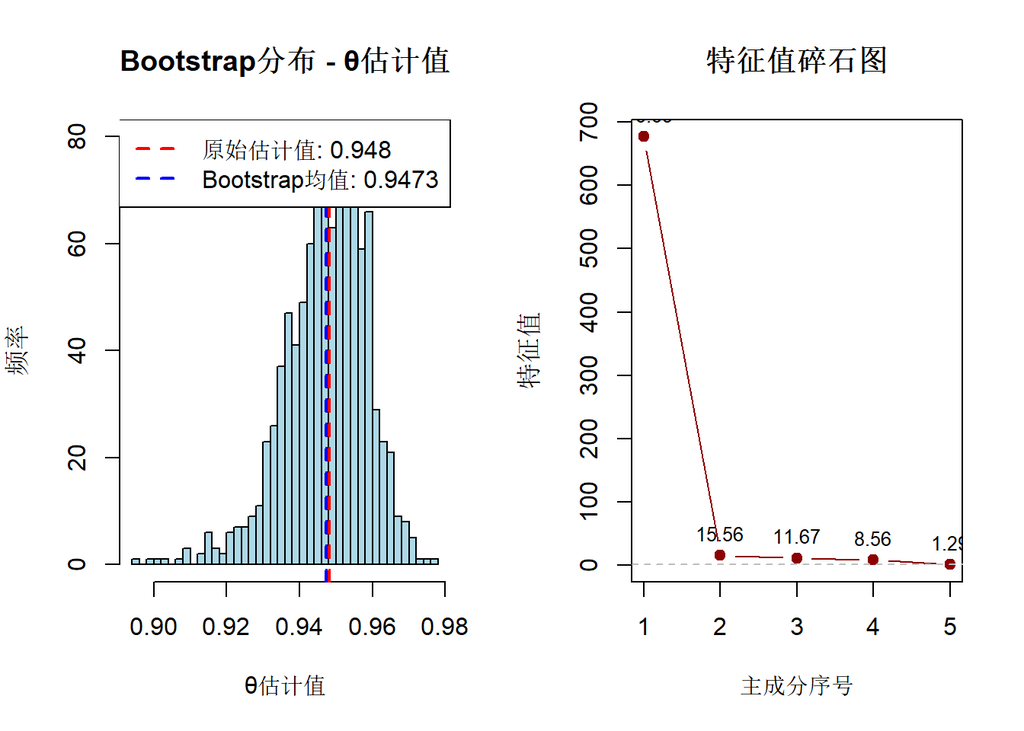

```
##
## 计算Bootstrap置信区间...
```

```
## BOOTSTRAP CONFIDENCE INTERVAL CALCULATIONS
## Based on 1000 bootstrap replicates
##
## CALL :
## boot.ci(boot.out = boot_results, type = c("norm", "basic", "perc",
##     "bca"))
##
## Intervals :
## Level      Normal              Basic
## 95%   ( 0.9266,  0.9710 )   ( 0.9296,  0.9748 )
##
## Level     Percentile            BCa
## 95%   ( 0.9213,  0.9665 )   ( 0.9213,  0.9665 )
## Calculations and Intervals on Original Scale
```

```
##
## === 练习8.7 结果总结 ===
```

```
## 数据集: scor (88名学生，5门科目)
```

```
## θ的原始估计值: 0.948
```

```
## Bootstrap偏差估计: -8e-04
```

```
## Bootstrap标准误估计: 0.0113
```